# Introduction to sc19011

Anran Liu

2020-01-02

## Overview

sc19011 provide function to deal with linear regression with sparse matrices and fill in missing data.

## mls

Sometimes, we get missing data, which is bad for fitting models. The mls function can fill in missing values, using local quadratic polynomial approximation.

The source R code for mls is as follows:

```r
mls <-  function(data_temp){
  b=0
  x0 <- which(data == 0)
  index <- seq(1,length(data_temp),1)/(length(data_temp))
  x0=x0/(length(data_temp))
  models <- function(x,theta){
    matrix(theta, nrow = 1,ncol = 3, byrow = T)%*%matrix(c(1-x^2,2*x*(1-x),x^2), nrow = 3, ncol = length(x),byrow = T)
  }
  loss = function(theta, x, y){
    sum(exp(-(x-x0)^2/0.4)*(y-models(x, theta))^2)
  }
  theta0 <- c(0, 0, 0, 0, 0, 0)
  theta.L <- optim(theta0, loss, x=index, y=data_temp, method = "BFGS")
  theta.L
  models(x0,theta.L$`par`)
  b = models(x0,theta.L$`par`)
  return(b)
}
```

For example We have a missing data in the sequence. Using mls function can give a value for the missing data, according to the neighborhood data.

```r
data <- c(1,2,3,0,3,2,1)
mls(data)
```

```
##          [,1]
## [1,] 2.027062
```

## RSC

The RSC function is used to estimate the rank of the regression coefficients.

```r
library(MASS)
RSC <-  function(x,y){
  p=ncol(x);nn=ncol(y) ;mm=min(nrow(x),nn)
  M=t(x)%*%x
  mpM=ginv(M) # M的MP逆
  P=x%*%mpM%*%t(x)
  V=as.matrix(eigen(t(y)%*%P%*%y)$vectors)
  hatB=mpM%*%t(x)%*%y
  W=hatB%*%V
  G=t(V)
  k<- mm
  hatBk<-array(0,dim=c(k,p,nn))
  RSC<-rep(0,k-1)
  mu=70
  for(kk in 2:k){
    #cat("rank=",kk,"\n")
    Wk=W[,1:kk]
    Gk=G[1:kk,]
    hatBk[kk-1,,]=Wk%*%Gk
    mse<-norm(y-x%*%hatBk[kk-1,,],type='F')^2
    pen<-mu*kk
    RSC[kk-1]<-mse+pen
  }
  rank<-which(RSC==min(RSC),arr.ind=TRUE)+1
  return(rank)
}
```

RSC will return the rank of the regression coefficients.

For example

In a linear model simulation, the data is sparse. RSC function can give the estimator of the rank for sparse regression coefficients.

```r
library(mvtnorm)
J <- 15
p <- 25
n <- 25
r=5
m=100
rho=0.1
sigma=1
b=0.4
Sigma <- matrix(0, nrow = p, ncol = p)
for (i in 1:p) {
  for (j in 1:p) {
    Sigma[i,j] <- rho^(abs(i-j))
  }
}
X <- matrix(0,nrow = m, ncol = p)
for (i in 1:m) {
  X[i,] <- rmvnorm(1,mean = rep(0,p), sigma=Sigma)
}
E <- matrix(0,nrow = m, ncol = n)
for (i in 1:m) {
  E[i,] <- rmvnorm(1,mean = rep(0,n), sigma=diag(n))
}
B0 <- matrix(0,nrow = J, ncol = r)
B1 <- matrix(0,nrow = r, ncol = n)
for (i in 1:J) {
  for (j in 1:r) {
    B0[i,j] <- rnorm(1)
  }
}
for (i in 1:r) {
  for (j in 1:n) {
    B1[i,j] <- rnorm(1)
  }
}
A <- matrix(0, nrow = p, ncol = n)
for (i in 1:J) {
  for (j in 1:n) {
    A[i,j] <- (b*B0%*%B1)[i,j]
  }
}
Y <- t(t(X))%*%A+E

RSC(X,Y)
```

```
## [1] 6
```

## assignment1

## Question3.4

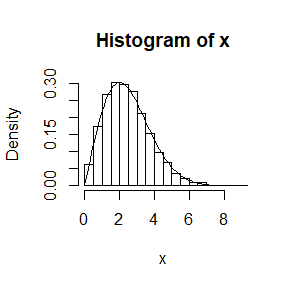

```r
n <- 4000
sigma <- 2
f1 <- function(x){
  x/sigma^2*exp(-0.5*x^2/sigma^2)
}
y <- runif(n)
x <- sqrt(-2*sigma^2*log(1-y))   #Inverse function
hist(x,prob = TRUE)
s <- seq(0, 10, .1)
lines(s,f1(s))
```

## Question3.11

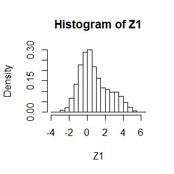

```r
n <- 1e4
X1 <- rnorm(n,0,1)
X2 <- rnorm(n,3,1)
i <- sample(c(0,1),n, replace = T, prob = c(0.25,0.75))
Z1 <- i*X1+(1-i)*X2
hist(Z1,prob = T)
```

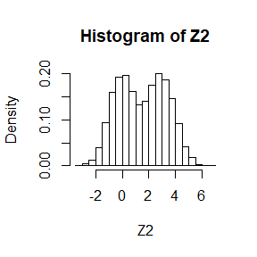

```r
#p=0.5, produce bimodal mixtures
i <- sample(c(0,1),n, replace = T)
Z2 <- i*X1+(1-i)*X2
hist(Z2,prob = T)
```

## Question3.18

```r
library(mvtnorm)
n <- 10
d <- 5
A <- rmvnorm(d,rep(0,d),diag(1,d))
A[upper.tri(A)] <- 0
for (i in 1:nrow(A)) {
  A[i,i] <- rchisq(1,n-i+1)
}
sigma <- matrix(diag(3,d),nrow = 5)
L <- chol(sigma)
X <- L%*%A%*%t(A)%*%t(L)   # Bartlett’s decomposition
X
```

```
##            [,1]       [,2]      [,3]       [,4]       [,5]
## [1,]  89.073761  -7.298989 -31.21524  20.816877  22.027618
## [2,]  -7.298989 380.890923 -36.78774 -28.543178  45.600965
## [3,] -31.215242 -36.787737 216.80374  41.178048 -67.214004
## [4,]  20.816877 -28.543178  41.17805  47.907932  -2.044219
## [5,]  22.027618  45.600965 -67.21400  -2.044219 177.238262
```

## assignment2

## Question5.1

```r
m <- 1e4
x <- runif(m,max = pi/3,min = 0)
g <-function(x) {pi/3*sin(x)}
theta <- sum(g(x))/m
theta
```

```
## [1] 0.4981397
```

```r
1-cos(pi/3) #true value
```

```
## [1] 0.5
```

## Question5.10

```r
MC.Phi <- function(x, R = 10000, antithetic = TRUE) {
  u <- runif(R/2,0,1)
  if (!antithetic) v <- runif(R/2,0,1) else v <- 1 - u
  u <- c(u, v)
  for (i in 1:length(x)) {
    g <- exp(-u)/(1+u^2)
    theta <- mean(g)
  }
  theta
}
m <- 1000
MC1 <- MC2 <- numeric(m)
x <- 1
for (i in 1:m) {
  MC1[i] <- MC.Phi(x, R = 1000, anti = FALSE)
  MC2[i] <- MC.Phi(x, R = 1000)
}
c(var(MC1),var(MC2),var(MC2)/var(MC1))
```

```
## [1] 5.432175e-05 2.204540e-06 4.058302e-02
```

## Question5.15

```r
library(knitr)
#Importance sampling
u <- runif(m)
x <- - log(1 - u * (1 - exp(-1)))
fg <- g(x) / (exp(-x) / (1 - exp(-1)))
est_im_mean <- mean(fg)
est_im_var <- var(fg)

#stratified importance sampling
M <- 10000
k <- 5 #group number
r <- M/k #replicates per stratum
N <- 50 #number of times to repeat the estimation
theta <- NULL

#divide interval
inter <- rep(0,k)
f <- function(x) -log(1-x*(1-exp(-1))) #Inverse function
for (i in 1:k-1) {
  inter[i] <- f(i/k)
}
inter[k] <- 1
inter <- c(0,inter)

#estimates
est <- NULL
for (j in 1:N) {
  g<-function(x) exp(-x)/(1+x^2)
  for (i in 1:k) {
    a <- inter[i]
    b <- inter[i+1]
    u=runif(m,a,b)
    x=-log(1-u*(1-exp(-1)))
    fg=g(x) / (1/(b-a)*exp(-x) / (1 - exp(-1)))
    theta[i] <- mean(fg)
  }
  est[j] <- sum(theta)
}
#result
c(mean(est), var(est))
```

```
## [1] 5.246826e-01 2.226767e-07
```

```r
#comparison between 5.10 and 5.15
c(est_im_mean,mean(est))
```

```
## [1] 0.4871684 0.5246826
```

```r
c(est_im_var,var(est))
```

```
## [1] 1.740861e-01 2.226767e-07
```

## assignment3

## Question6.5

```r
n <- 20
alpha <- 0.975
UCL <- replicate(1000, expr = {
  x <- rchisq(n,2)
  est_min <- mean(x) - qt(0.975,n-1)*sd(x)/sqrt(n)
  est_max <- mean(x) + qt(0.975,n-1)*sd(x)/sqrt(n)
  est_max>2 & est_min<2
} )
mean(UCL) #coverage probability
```

```
## [1] 0.913
```

```r
#example6.4
n <- 20
alpha <- .05
UCL <- replicate(1000, expr = {
  x <- rchisq(n, 2)
  (n-1) * var(x) / qchisq(alpha, df = n-1)
} )
mean(UCL>4)  #coverage probability
```

```
## [1] 0.769
```

## Question6.6

```r
b <- NULL
n=1e4
sk <- function(x) {
  #computes sample skewness
  xbar <- mean(x)
  m3 <- mean((x - xbar)^3)
  m2 <- mean((x - xbar)^2)
  return( m3 / m2^1.5 )
}
num <- 1e2
for (i in 1:num) {
    x <- rnorm(n)
    b[i] <- sk(x)
}
q <- c(0.025,0.05,0.95,0.975)
quantile(b,q)   #estimates
```

```
##        2.5%          5%         95%       97.5%
## -0.05436519 -0.04077503  0.03190940  0.04381030
```

```r
f <- function(x){
  f <- exp(-x^2/(12*(n-2)/((n+1)*(n+3))))/sqrt(2*pi*(6*(n-2)/((n+1)*(n+3))))
}
var_b <- q*(1-q)/(n*f(quantile(b,q))^2)
var_b  #var of skewness
```

```
##         2.5%           5%          95%        97.5%
## 1.269447e-06 2.863640e-07 9.777124e-08 2.254836e-07
```

```r
cv <- qnorm(q, 0, sqrt(6/n)) # large sample approximation
cv
```

```
## [1] -0.04800912 -0.04029052  0.04029052  0.04800912
```

## assignment4

## Question6.7

```r
set.seed(233)
pwr <- NULL
sk <- function(x) {
  #computes sample skewness
  xbar <- mean(x)
  m3 <- mean((x - xbar)^3)
  m2 <- mean((x - xbar)^2)
  return( m3 / m2^1.5 )
}
num <- 100  #Total number of samples
repnum <- 1e4
sktests <- numeric(repnum)
cv <- qnorm(1-0.05/2, 0, sqrt(6*(num-2) / ((num+1)*(num+3))))

#beta distribution
for (i in 1:repnum) { #for each replicate
  x <- rbeta(num, 2, 2)
  sktests[i] <- as.integer(abs(sk(x)) >= cv)
}
pwr <- mean(sktests)
pwr
```

```
## [1] 0.0017
```

```r
#t distribution
for (i in 1:repnum) {
  x <- rt(num, 3)
  sktests[i] <- as.integer(abs(sk(x)) >= cv)
}
pwr <- mean(sktests)
pwr
```

```
## [1] 0.6434
```

## Question6.A

```r
n <- 200
alpha <- .05
mu0 <- 1
m <- 10000 #number of replicates
p <- matrix(NA, nrow = m, ncol = 3)
for (j in 1:m) {
  x <- rchisq(n, 1)
  y <- runif(n,0,2)
  z <- rexp(n,1)
  ttest <- t.test(x, alternative = "two.sided", mu = mu0)
  p[j,1] <- ttest$p.value
  ttest <- t.test(y, alternative = "two.sided", mu = mu0)
  p[j,2] <- ttest$p.value
  ttest <- t.test(z, alternative = "two.sided", mu = mu0)
  p[j,3] <- ttest$p.value
}
type1 <- apply(p < alpha, 2, mean)
names(type1) <- c('chi-square','union','exp')
#type1error
type1
```

```
## chi-square      union        exp
##     0.0535     0.0484     0.0563
```

## Discussion

(1)H0:power1=power2 $\leftrightarrow$ H1:power1!=power2

(2)McNemar test

(3)True positive rate

We know power means we can get False negative rate, so we need True positive rate for McNemar test.

## assignment6

## Question7.8

```r
set.seed(123)
library(bootstrap)
lambda_hat <- eigen(cov(scor))$values
theta_hat <- lambda_hat[1]/sum(lambda_hat)
B <- 200
# Jackknife
theta_j <- rep(0,nrow(scor))
for (i in 1:nrow(scor)) {
  x <- scor [-i,]
  lambda <- eigen(cov(x))$values
  theta_j[i] <- lambda[1]/sum(lambda)
}
bias_jack <- mean(theta_j)-theta_hat
se_jack <- sqrt(var(theta_j))
#bias
bias_jack
```

```
## [1] 1.228895e-05
```

```r
# standard error
se_jack
```

```
## [1] 0.00534301
```

## Question7.10

```r
library(DAAG)
attach(ironslag)
set.seed(123)
n <- length(magnetic)
e1 <- e2 <- e3 <- e4 <- numeric(n)
rsq <- matrix(0,nrow = n, ncol = 4)
# for n-fold cross validation
# fit models on leave-one-out samples
for (k in 1:n) {
  y <- magnetic[-k]
  x <- chemical[-k]
  J1 <- lm(y ~ x)
  yhat1 <- J1$coef[1] + J1$coef[2] * chemical[k]
  e1[k] <- magnetic[k] - yhat1
  rsq[k,1] <- summary(J1)$`adj.r.squared`

  J2 <- lm(y ~ x + I(x^2))
  yhat2 <- J2$coef[1] + J2$coef[2] * chemical[k] +
    J2$coef[3] * chemical[k]^2
  e2[k] <- magnetic[k] - yhat2
  rsq[k,2] <- summary(J2)$`adj.r.squared`

  J3 <- lm(log(y) ~ x)
  logyhat3 <- J3$coef[1] + J3$coef[2] * chemical[k]
  yhat3 <- exp(logyhat3)
  e3[k] <- magnetic[k] - yhat3
  rsq[k,3] <- summary(J3)$`adj.r.squared`

  J4 <- lm(y ~ x + I(x^2) + I(x^3))
  yhat4 <- J4$coef[1] + J4$coef[2] * chemical[k] +
    J4$coef[3] * chemical[k]^2 + J4$coef[4] * chemical[k]^3
  e4[k] <- magnetic[k] - yhat4
  rsq[k,4] <- summary(J4)$`adj.r.squared`
}
error <- c(mean(e1^2), mean(e2^2), mean(e3^2), mean(e4^2))
rsqu <- colMeans(rsq)
cv_select<- matrix(c(error,rsqu),nrow = 2, ncol = 4, byrow = T, dimnames = list(c("error",'rsq'),
                               c('model1','model2','model3','model4')))
knitr::kable(cv_select)
```

|  | model1 | model2 | model3 | model4 |
| --- | --- | --- | --- | --- |
| error | 19.5564444 | 17.8524751 | 18.4418785 | 18.1775605 |
| rsq | 0.5279975 | 0.5765627 | 0.5279427 | 0.5736991 |

According to the prediction error and adjusted $R^2$, Model 2, the quadratic model, would be the best fit for the data.

## assignment8

## Question9.4

```r
set.seed(1234)
library(GeneralizedHyperbolic)
```

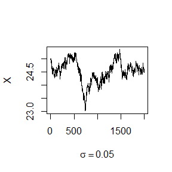

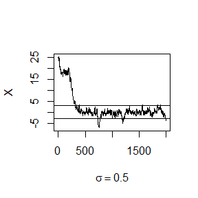

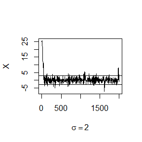

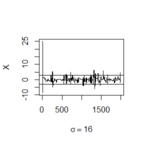

```r
rw.Metropolis <- function(n, sigma, x0, N) {
  x <- numeric(N)
  x[1] <- x0
  u <- runif(N)
  k <- 0
  for (i in 2:N) {
    y <- rnorm(1, x[i-1], sigma)
    if (u[i] <= (dskewlap(y, mu = 0, alpha = 1, beta = 1) / dskewlap(x[i-1], mu = 0, alpha = 1, beta = 1)))
      x[i] <- y  else {
        x[i] <- x[i-1]
        k <- k + 1
      }
  }
  return(list(x=x, k=k))
}

N <- 2000
sigma <- c(.05, .5, 2, 16)

x0 <- 25
rw1 <- rw.Metropolis(n, sigma[1], x0, N)
rw2 <- rw.Metropolis(n, sigma[2], x0, N)
rw3 <- rw.Metropolis(n, sigma[3], x0, N)
rw4 <- rw.Metropolis(n, sigma[4], x0, N)

par(mfrow=c(1,1))  #display 4 graphs together
refline <- qskewlap(c(.025, .975), mu = 0, alpha = 1, beta = 1)
rw <- cbind(rw1$x, rw2$x, rw3$x,  rw4$x)
for (j in 1:4) {
  plot(rw[,j], type="l",
       xlab=bquote(sigma == .(round(sigma[j],3))),
       ylab="X", ylim=range(rw[,j]))
  abline(h=refline)
}
```

```r
#number of candidate points accepted
print(1-c(rw1$k/N, rw2$k/N, rw3$k/N, rw4$k/N))
```

```
## [1] 0.9785 0.8375 0.5355 0.1055
```

## assignment9

## Question11.1

```r
x <- c(1:100)
isTRUE(all.equal(log(exp(x)),exp(log(x))))
```

```
## [1] TRUE
```

```r
isTRUE(log(exp(x)) == exp(log(x)))
```

```
## [1] FALSE
```

## Question11.5

```r
a <- 1
ck <- function(x,k){
  sqrt(x^2*k/(k+1-x^2))
}
left <- function(x,k){
  f <- function(u) {
    (1+u^2/(k-1))^(-k/2)
  }
  2*gamma(k/2)/(sqrt(pi*(k-1))*gamma((k-1)/2))*integrate(f, lower=0, upper=ck(x,k-1))$value
}

g <- function(x,k){
  left(x,k)-left(x,k+1)
}

uniroot(g,c(1,2), k=10)$`root`
```

```
## [1] 1.62539
```

```r
uniroot(g,c(1,2), k=25)$`root`
```

```
## [1] 1.687373
```

```r
uniroot(g,c(4,5), k=25)$`root`
```

```
## [1] 4.999835
```

```r
uniroot(g,c(1,2), k=100)$`root`
```

```
## [1] 1.720608
```

## Slides

```r
na <- 28
nb <- 24
noo <- 41
nab <- 70
n <- 163

#max likelihood f
logL <- function(theta){
  p <- theta[1]
  q <- theta[2]
  r <- 1-q-p
  ll <- 2*na*log(p)+2*nb*log(q)+2*noo*log(r)+nao*log(2*r/p)+nbo*log(2*r/q)+nab*log(2*p*q)
  return(-ll)
}
# set p0
theta <- c(0.1, 0.1)
flag <- 1e-10
Lold <- NULL
Lold[1] <- 0
for (i in 1:20) {
  #E step
  p <- theta[1]
  q <- theta[2]
  r <- 1-p-q
  nao <- na*(2*r/(p+2*r))
  nbo <- nb*(2*r/(q+2*r))
  #M step
  fit <- optim(c(0.1, 0.1), logL)
  theta[1] <- fit$par[1]    #update p q
  theta[2] <- fit$par[2]
  Lold[i+1] <- logL(theta)   #the likelihood value
  if (abs(Lold[i]-Lold[i+1]) < flag) break
}
theta #p & q
```

```
## [1] 0.3273325 0.3104528
```

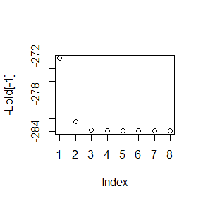

```r
plot(-Lold[-1])
```

I feel strange that the log-maximum likelihood values decrease.

## assignment10

## Page204.3

```r
formulas <- list(
  mpg ~ disp,
  mpg ~ I(1 / disp),
  mpg ~ disp + wt,
  mpg ~ I(1 / disp) + wt
)
for (x in formulas) {     #use for
  print(lm(x,mtcars))
}
```

```
##
## Call:
## lm(formula = x, data = mtcars)
##
## Coefficients:
## (Intercept)         disp
##    29.59985     -0.04122
##
##
## Call:
## lm(formula = x, data = mtcars)
##
## Coefficients:
## (Intercept)    I(1/disp)
##       10.75      1557.67
##
##
## Call:
## lm(formula = x, data = mtcars)
##
## Coefficients:
## (Intercept)         disp           wt
##    34.96055     -0.01772     -3.35083
##
##
## Call:
## lm(formula = x, data = mtcars)
##
## Coefficients:
## (Intercept)    I(1/disp)           wt
##      19.024     1142.560       -1.798
```

```r
model1 <- lapply(formulas,lm,data = mtcars) #use lapply
```

## 4

```r
bootstraps <- lapply(1:10, function(i) {
  rows <- sample(1:nrow(mtcars), rep = TRUE)
  mtcars[rows, ]
})

model2 <- lapply(bootstraps, lm, formula = mpg ~ disp)   #use lapply
for (x in bootstraps) {           #use for
  print(lm(formula = mpg ~ disp,x))
}
```

```
##
## Call:
## lm(formula = mpg ~ disp, data = x)
##
## Coefficients:
## (Intercept)         disp
##    30.39519     -0.03939
##
##
## Call:
## lm(formula = mpg ~ disp, data = x)
##
## Coefficients:
## (Intercept)         disp
##    30.91963     -0.04457
##
##
## Call:
## lm(formula = mpg ~ disp, data = x)
##
## Coefficients:
## (Intercept)         disp
##    28.80275     -0.03587
##
##
## Call:
## lm(formula = mpg ~ disp, data = x)
##
## Coefficients:
## (Intercept)         disp
##     28.1861      -0.0393
##
##
## Call:
## lm(formula = mpg ~ disp, data = x)
##
## Coefficients:
## (Intercept)         disp
##    28.39297     -0.03961
##
```

[output cut: 24 more lines]

```
##
## Call:
## lm(formula = mpg ~ disp, data = x)
##
## Coefficients:
## (Intercept)         disp
##    30.31619     -0.04278
##
##
## Call:
## lm(formula = mpg ~ disp, data = x)
##
## Coefficients:
## (Intercept)         disp
##    32.02928     -0.05091
```

## 5

```r
rsq <- function(mod) summary(mod)$r.squared
sapply(model1, rsq)
```

```
## [1] 0.7183433 0.8596865 0.7809306 0.8838038
```

```r
sapply(model2, rsq)
```

```
##  [1] 0.6500630 0.7150100 0.6241672 0.7467115 0.7864469 0.5647385 0.7696329
##  [8] 0.7915227 0.7171326 0.7364533
```

#page214 3

```r
trials <- replicate(
  100,
  t.test(rpois(10, 10), rpois(7, 10)),
  simplify = FALSE
)
sapply(trials, '[[', 3)
```

```
##   [1] 0.088501997 0.782229472 0.558778724 0.504172365 0.268636294
##   [6] 0.292261276 0.117957446 0.406056353 0.074940651 0.885377316
##  [11] 0.385356392 0.879155662 0.795810517 0.459151185 0.590971420
##  [16] 0.379953570 0.528057143 0.887524574 0.062198775 0.035929400
##  [21] 0.111404491 0.747426792 0.028251391 0.573227941 0.008865798
##  [26] 0.679153695 0.871081299 0.889653225 0.594543316 0.130047501
##  [31] 0.898272500 0.127448333 0.847326915 0.514941351 0.458522608
##  [36] 0.032246013 0.865008405 0.890360125 0.399394375 0.502907375
##  [41] 0.101222289 0.671935015 0.767077386 0.879708678 0.281205952
##  [46] 0.559491548 0.326711541 0.392127859 0.264878684 0.017180113
##  [51] 0.302249210 0.865878227 0.454601854 0.704462193 0.303978093
##  [56] 0.994687375 0.006480437 0.789568030 0.483631449 0.697195305
##  [61] 0.391507213 0.671956348 0.596340317 0.739500324 0.863811213
##  [66] 0.586462308 0.118613821 0.446116214 0.636416998 0.239816233
##  [71] 0.830042152 0.028641079 0.826582887 0.342440165 0.804668472
##  [76] 0.259549055 0.316490011 0.049305241 0.295631169 0.463542093
##  [81] 0.423105364 0.472308503 0.911421333 0.802333436 0.623767689
##  [86] 0.608417785 0.966238532 0.141146986 0.240193791 0.541827880
##  [91] 0.957893625 0.593465819 0.337388315 0.138872293 0.646903605
##  [96] 0.845998434 0.437561076 0.074536050 0.813054218 0.707169342
```

#7

```r
library(devtools)
library(parallelsugar)
library(parallel)
boot_df <- function(x) x[sample(nrow(x), rep = T), ]
rsquared <- function(mod) summary(mod)$r.square
boot_lm <- function(i) {
  dat <- boot_df(mtcars)
  rsquared(lm(mpg ~ wt + disp, data = dat))
}
n <- 1e2
#system.time(mclapply(1:n, boot_lm, mc.cores = 4))

mclapply(1:4, boot_lm, mc.cores = 1)
```

```
## [[1]]
## [1] 0.8253807
##
## [[2]]
## [1] 0.8133341
##
## [[3]]
## [1] 0.8486859
##
## [[4]]
## [1] 0.7921987
```

```r
mcsapply<- function(x,f,n){  #mcsapply function
  unlist(mclapply(x,f,mc.cores = n))
}
mcsapply(1:4, boot_lm,1)
```

```
## [1] 0.8223110 0.7675184 0.7216745 0.7753240
```

```r
unlist(mclapply(1:4, boot_lm, mc.cores = 1))
```

```
## [1] 0.6912752 0.8360858 0.7808135 0.7975885
```

## assignment11

```r
library(GeneralizedHyperbolic)
library(microbenchmark)
#using c++
library(Rcpp)
dir_cpp <- '../src/'
# Can create source file in Rstudio
sourceCpp(paste0(dir_cpp,"rw.cpp"))
```

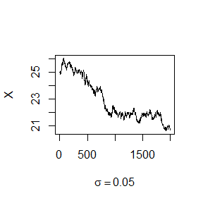

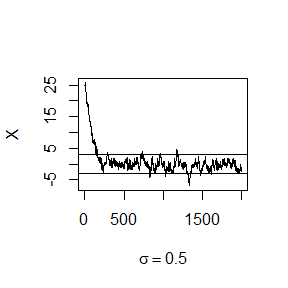

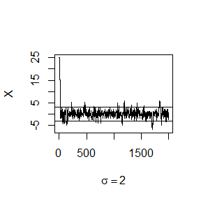

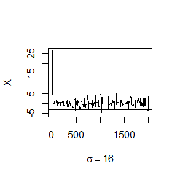

```r
N <- 2000
sigma <- c(.05, .5, 2, 16)
x0 <- 25
rw1c <- rwMetropolisC(sigma[1], x0, N)
rw2c <- rwMetropolisC(sigma[2], x0, N)
rw3c <- rwMetropolisC(sigma[3], x0, N)
rw4c <- rwMetropolisC(sigma[4], x0, N)
rwc <- cbind(rw1c, rw2c, rw3c,  rw4c)
par(mfrow=c(1,1))
refline <- qskewlap(c(.025, .975), mu = 0, alpha = 1, beta = 1)
for (j in 1:4) {
  plot(rwc[,j], type="l",
       xlab=bquote(sigma == .(round(sigma[j],3))),
       ylab="X", ylim=range(rwc[,j]))
  abline(h=refline)
}
```

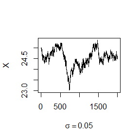

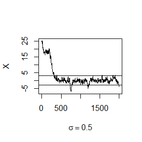

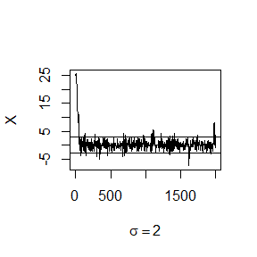

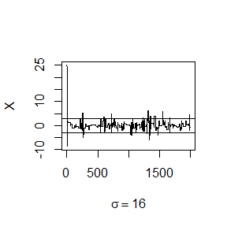

```r
#using r
set.seed(1234)
lap_f = function(x) exp(-abs(x))
rw.Metropolis = function(sigma, x0, N){
  x = numeric(N)
  x[1] = x0
  u = runif(N)
  k = 0
  for (i in 2:N) {
    y = rnorm(1, x[i-1], sigma)
    if (u[i] <= (lap_f(y) / lap_f(x[i-1]))) x[i] = y
    else {
      x[i] = x[i-1]
      k = k+1
    }
  }
  return(list(x = x, k = k))
}

N <- 2000
sigma <- c(.05, .5, 2, 16)
x0 <- 25
rw1 <- rw.Metropolis(sigma[1], x0, N)
rw2 <- rw.Metropolis(sigma[2], x0, N)
rw3 <- rw.Metropolis(sigma[3], x0, N)
rw4 <- rw.Metropolis(sigma[4], x0, N)
par(mfrow=c(1,1))  #display 4 graphs together
refline <- qskewlap(c(.025, .975), mu = 0, alpha = 1, beta = 1)
rw <- cbind(rw1$x, rw2$x, rw3$x,  rw4$x)
for (j in 1:4) {
  plot(rw[,j], type="l",
       xlab=bquote(sigma == .(round(sigma[j],3))),
       ylab="X", ylim=range(rw[,j]))
  abline(h=refline)
}
```

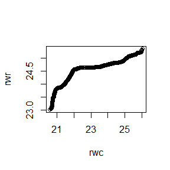

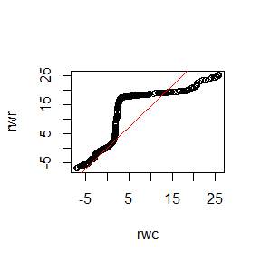

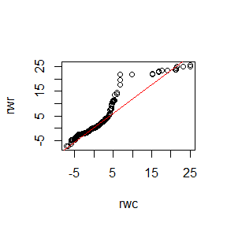

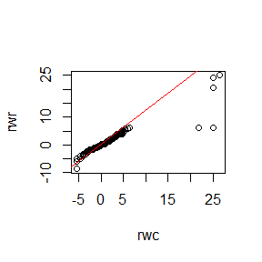

```r
##qqplot
for (j in 1:4) {
  qqplot(rwc[,j], rw[,j], xlab = 'rwc', ylab = 'rwr')
  qqline(rwc[,j], col = 2)
}
```

```r
## compare the computation time
ts <- microbenchmark(rwR=rw.Metropolis(sigma[1], x0, N), rwC=rwMetropolisC(sigma[1], x0, N))
summary(ts)[,c(1,3,5,6)]
```

```
##   expr      lq  median      uq
## 1  rwR 7130.15 7555.10 8893.65
## 2  rwC  364.65  378.55  403.00
```

we can get shorter calculation time using method rcpp.